# Hello R

Quang Le - DATA 2401

2/12/2025

### Load packages

```r
library(tidyverse)
library(datasauRus)
```

### Exercise 1

*In this Exercise, the datasauRus has:*

- 1846 rows,
- 3 columns **(including dataset, x, and y values)**
  - *dataset:* this column shows where the entries are form.
  - *x:* it represents x values.
  - *y:* it represents y values.

### Exercise 2

*First let’s plot the data in the dino dataset:*

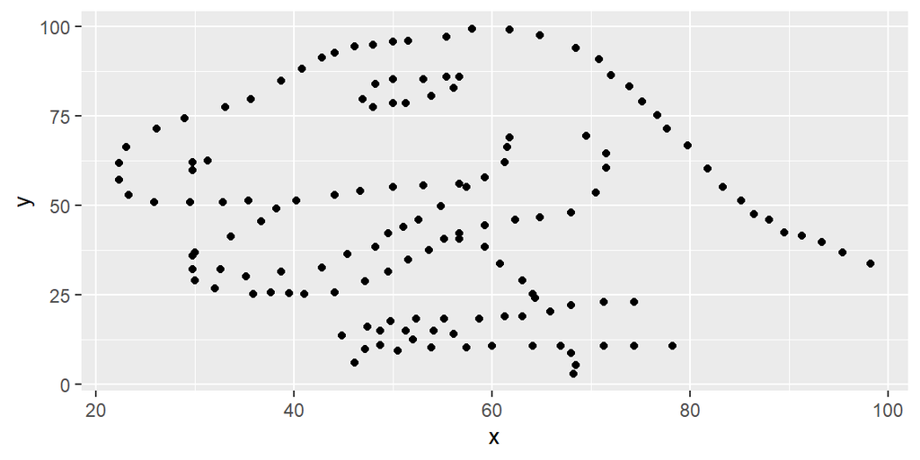

```r
dino_data <- datasaurus_dozen %>%
  filter(dataset == "dino")
ggplot(data = dino_data, mapping = aes(x = x, y = y)) +
  geom_point()
```

*And next calculate the correlation between `x` and `y` in this dataset:*

```r
dino_data %>%
  summarize(r = cor(x, y))
```

```
## # A tibble: 1 × 1
##         r
##     <dbl>
## 1 -0.0645
```

*Answer:* **r_dino = -0.0645**

### Exercise 3

*First of all, let’s plot the data in the star data set:*

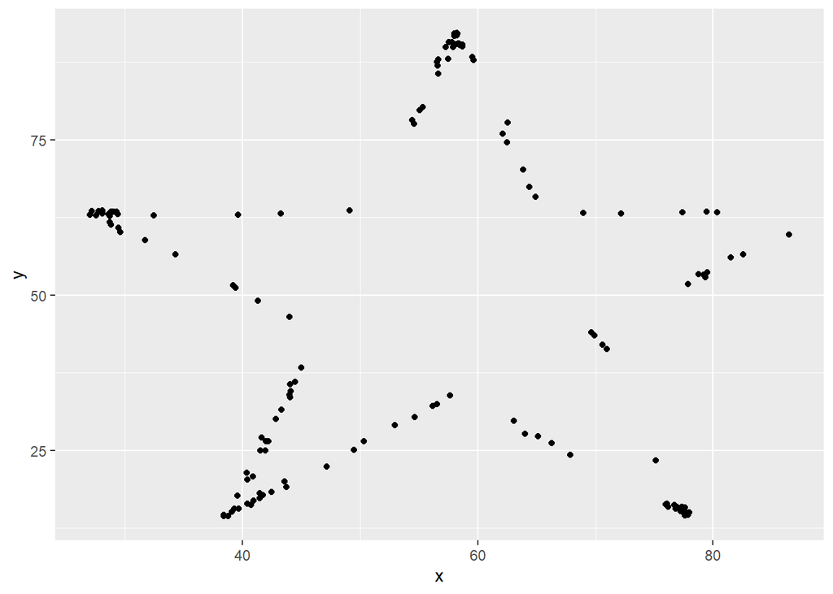

```r
star_data <- datasaurus_dozen %>%
  filter(dataset == "star")
ggplot(data = star_data, mapping = aes(x = x, y = y))+
  geom_point()
```

*Next, calculate the correlation between x and y in this data set:*

```r
star_data %>%
  summarise(r_star = cor(x, y))
```

```
## # A tibble: 1 × 1
##    r_star
##     <dbl>
## 1 -0.0630
```

*Answer:* **r = -0.0630**

> **Comparison** **the difference value between *r_star* and *r_dino.***

| **r_star** | **r_dino** | **The difference** |
| --- | --- | --- |
| *-0.063* | *-0.0645* | *star data is .0015 higher than that of dino data* |

### Exercise 4

*First step: Let’s plot the data in the circle data set:*

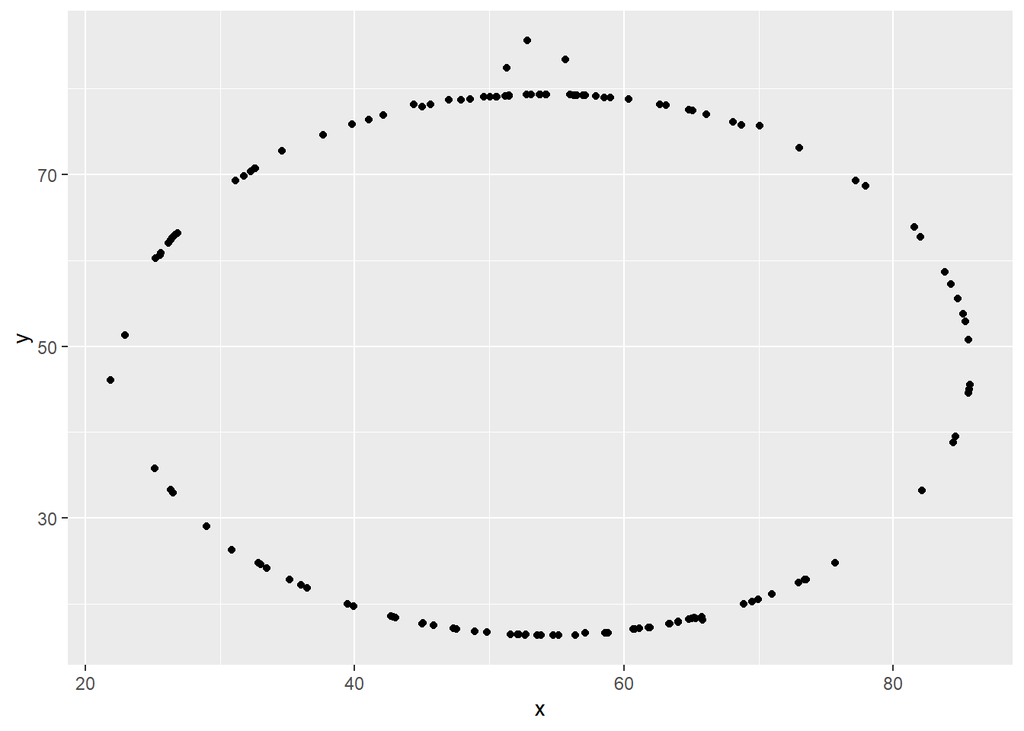

```r
circle_data <- datasaurus_dozen %>%
  filter(dataset == "circle")
ggplot(data = circle_data, mapping = aes(x = x, y = y)) +
  geom_point()
```

*Next step is check for unique values in the data columns. When filter the “circle”, a star was shown accidentally.*

*Note:* It can be fixed after pasting code from Exercise 3 to Exercise 4 by editing the argument data = star_data in lieu of circle_data.

```r
unique_values <- unique(dino_data$dataset)

#Print the unique values
print(unique_values)
```

```
## [1] "dino"
```

*Then, calculate the correlation between x and y in the data set:*

```r
circle_data %>%
  summarise(r_circle = cor(x,y))
```

```
## # A tibble: 1 × 1
##   r_circle
##      <dbl>
## 1  -0.0683
```

*Answer:* **r_circle = -0.0683**

> **Comparison *the diffrence between r_circle and r_dino***

> | **r_cirle** | **r_dino** | **The difference** |
> | --- | --- | --- |
> | -0.0683 | -0.0645 | *circle is 0.0038 lower than that of dino.* |

### Exercise 5

*Final step: Plot all data st at once.*

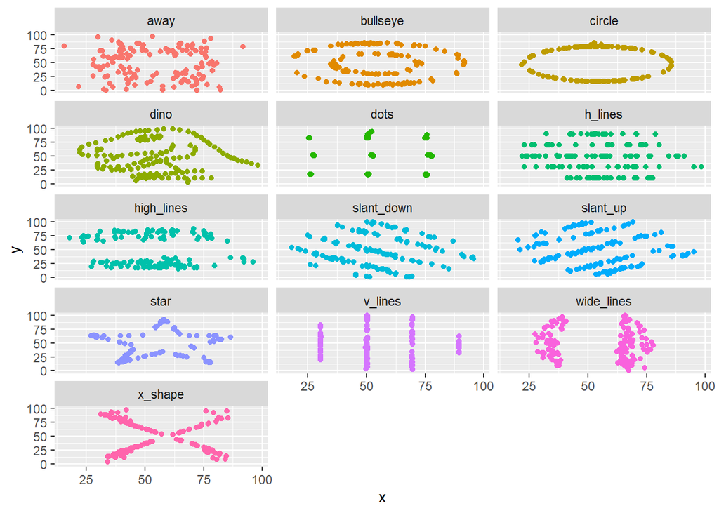

```r
ggplot(datasaurus_dozen, aes(x = x, y = y, color = dataset)) + geom_point()+
  facet_wrap(~ dataset, ncol = 3) +
  theme(legend.position = "none")
```

*After that, utilize the ‘group_by’ function to generate all the summary of correlation coefficients.*

```r
datasaurus_dozen %>%
  group_by(dataset) %>%
  summarise(r = cor(x, y))
```

```
## # A tibble: 13 × 2
##    dataset          r
##    <chr>        <dbl>
##  1 away       -0.0641
##  2 bullseye   -0.0686
##  3 circle     -0.0683
##  4 dino       -0.0645
##  5 dots       -0.0603
##  6 h_lines    -0.0617
##  7 high_lines -0.0685
##  8 slant_down -0.0690
##  9 slant_up   -0.0686
## 10 star       -0.0630
## 11 v_lines    -0.0694
## 12 wide_lines -0.0666
## 13 x_shape    -0.0656
```